# Reproducible Research Course Project 1

Joshua Stein

2024-03-27

# Introduction

In this document, I will download a dataset provided by Professor Roger Peng as part of the Reproducible Research Class on Coursera. The dataset describes activity monitoring data from personal fitness monitoring devices. In this document, the datset will be loaded and processed in RStudio, and several questions regarding the dataset will be investigated.

# Loading and Processing the Data

The data was first loaded into RStudio and processed for proper analysis.

```r
url <- "https://d396qusza40orc.cloudfront.net/repdata%2Fdata%2Factivity.zip"
download.file(url, destfile = "/Users/joshuastein/Desktop/hello-world/ReproducibleResearch/CourseProject1/data.zip", mode = "wb")

unzip("/Users/joshuastein/Desktop/hello-world/ReproducibleResearch/CourseProject1/data.zip")

data <- read.csv("activity.csv", na.strings = "NA")
data$date <- as.Date(data$date)
```

# How many steps were taken each day?

The cut and aggregate functions were used to determine the number of steps taken per day.

```r
dateintervals <- cut(data$date, breaks = "day")
stepsbydate <- aggregate(steps ~ dateintervals, data = data, FUN = sum, na.action = na.pass)
```

The number of steps per day seems to widely variable from below 50 to over 20,000 steps per day.

```r
library(knitr)
kable(stepsbydate)
```

| dateintervals | steps |
| --- | --- |
| 2012-10-01 | NA |
| 2012-10-02 | 126 |
| 2012-10-03 | 11352 |
| 2012-10-04 | 12116 |
| 2012-10-05 | 13294 |
| 2012-10-06 | 15420 |
| 2012-10-07 | 11015 |
| 2012-10-08 | NA |
| 2012-10-09 | 12811 |
| 2012-10-10 | 9900 |
| 2012-10-11 | 10304 |
| 2012-10-12 | 17382 |
| 2012-10-13 | 12426 |
| 2012-10-14 | 15098 |
| 2012-10-15 | 10139 |
| 2012-10-16 | 15084 |
| 2012-10-17 | 13452 |
| 2012-10-18 | 10056 |
| 2012-10-19 | 11829 |
| 2012-10-20 | 10395 |
| 2012-10-21 | 8821 |
| 2012-10-22 | 13460 |
| 2012-10-23 | 8918 |
| 2012-10-24 | 8355 |
| 2012-10-25 | 2492 |
| 2012-10-26 | 6778 |
| 2012-10-27 | 10119 |
| 2012-10-28 | 11458 |
| 2012-10-29 | 5018 |
| 2012-10-30 | 9819 |
| 2012-10-31 | 15414 |
| 2012-11-01 | NA |
| 2012-11-02 | 10600 |
| 2012-11-03 | 10571 |
| 2012-11-04 | NA |
| 2012-11-05 | 10439 |
| 2012-11-06 | 8334 |
| 2012-11-07 | 12883 |
| 2012-11-08 | 3219 |
| 2012-11-09 | NA |
| 2012-11-10 | NA |
| 2012-11-11 | 12608 |
| 2012-11-12 | 10765 |
| 2012-11-13 | 7336 |
| 2012-11-14 | NA |
| 2012-11-15 | 41 |
| 2012-11-16 | 5441 |
| 2012-11-17 | 14339 |
| 2012-11-18 | 15110 |
| 2012-11-19 | 8841 |
| 2012-11-20 | 4472 |
| 2012-11-21 | 12787 |
| 2012-11-22 | 20427 |
| 2012-11-23 | 21194 |
| 2012-11-24 | 14478 |
| 2012-11-25 | 11834 |
| 2012-11-26 | 11162 |
| 2012-11-27 | 13646 |
| 2012-11-28 | 10183 |
| 2012-11-29 | 7047 |
| 2012-11-30 | NA |

The mean and median were also calculated:

```r
mean(stepsbydate$step, na.rm = TRUE)
```

```
## [1] 10766.19
```

```r
median(stepsbydate$steps, na.rm = TRUE)
```

```
## [1] 10765
```

The data was also graphed on a histogram for visualization. The majority of total steps seem to fluctuate between 10,000 and 15,000 steps per day:

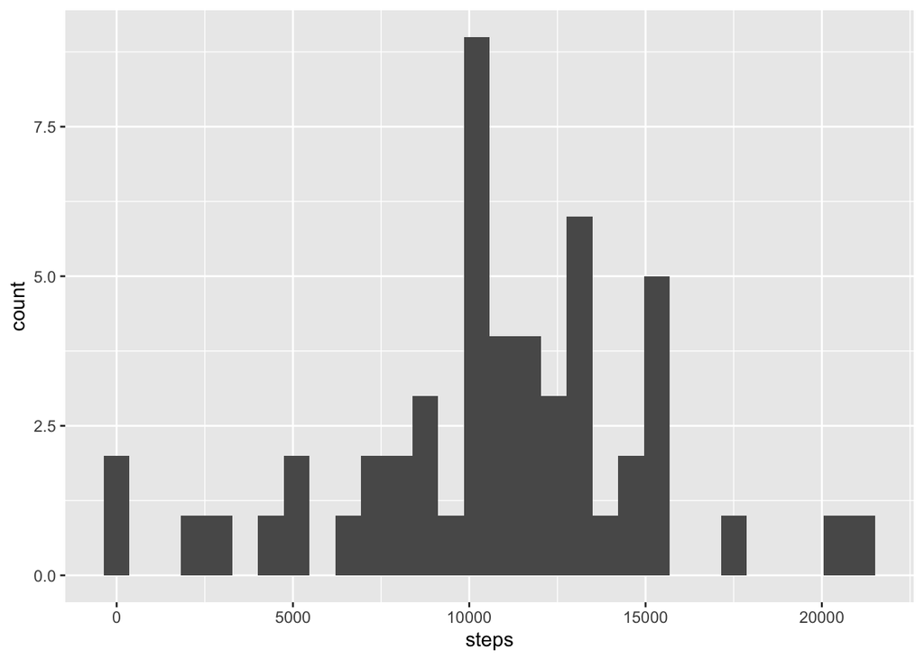

```r
library(ggplot2)
g <- ggplot(data = stepsbydate, aes(x = steps)) + geom_histogram()
print(g)
```

# What is the average daily activity pattern?

It’s apparent that the daily number of steps widely varies. In this section, we investigated potential patterns to daily activity by creating a Time Series Plot and looking at 5-minute interval:

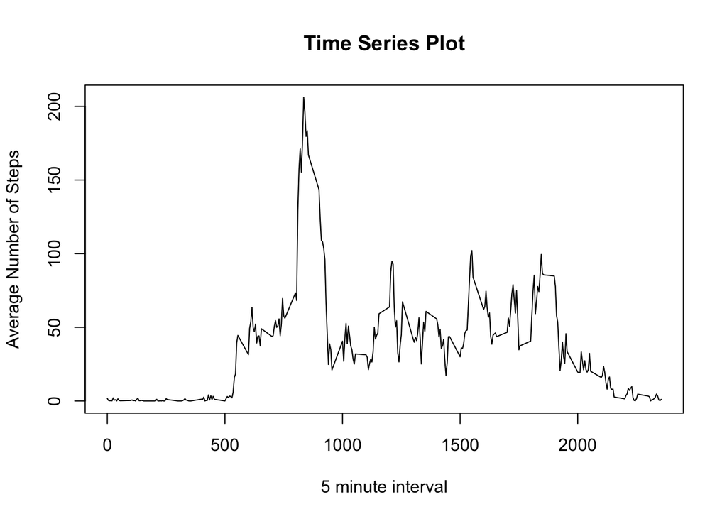

```r
patternandsteps <- cut(data$date, breaks = "day")
stepsbyinterval <- aggregate(steps ~ interval, data = data, FUN = mean)
plot(stepsbyinterval$interval, stepsbyinterval$steps, type = "l", xlab = "5 minute interval", ylab = "Average Number of Steps", main = "Time Series Plot")
```

The 5-minute interval with the highest average number of steps is 835:

```r
indexnum <- which.max(stepsbyinterval$steps)
print(stepsbyinterval$interval[indexnum])
```

```
## [1] 835
```